# Processing data and making figures

This notebook opens a Nanosurf image file, levels it, masks the features so they do not disturb the leveling, and makes figures for a report. Run it from this folder, next to `MoS2.nid`.

```python
from NSFopen.process import process

import matplotlib.pyplot as plt
```

## Open the file

`afm.channels` lists what the file holds. Every processing and plot function works on one channel, by default the forward height. `afm.array()` gives a channel as a plain array in SI units, for your own calculations.

```python
afm = process("MoS2.nid")
print(afm.channels)

z = afm.array()  # the forward height, in m
width, height = afm.size()  # in m
print(f"{z.shape[1]} x {z.shape[0]} pixels, {width * 1e6:.2f} x {height * 1e6:.2f} um, unit {afm.unit()}")
```

```
{'Forward': ['Z-Axis', 'Amplitude', 'Phase', 'Z-Axis Sensor'], 'Backward': ['Z-Axis', 'Amplitude', 'Phase', 'Z-Axis Sensor']}
512 x 256 pixels, 3.97 x 3.97 um, unit m
```

## Level the lines

`flatten` subtracts a straight line from every scan line. The unit, labels and color bar come from the file. `color_range='p1'` leaves the top and bottom 1 % of the pixels out of the color scale, so a few spikes cannot wash out the picture.

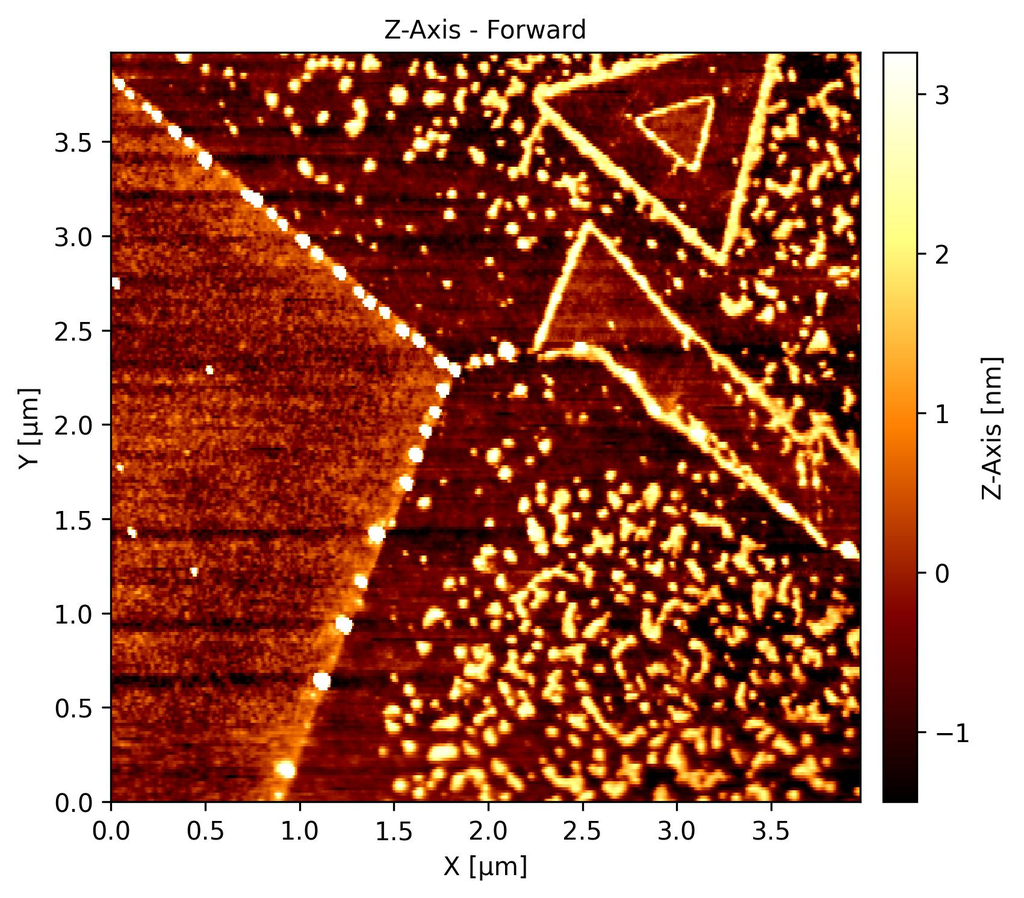

```python
afm.flatten(order=1)

fig = afm.image(color_range="p1")
plt.show()
```

The bright islands pull the fit of every line they cross, which leaves dark bands beside them. To fix that, mask everything higher than 2 nm and fit the lines only to the rest. Heights are in m, so 2 nm is `2e-9`.

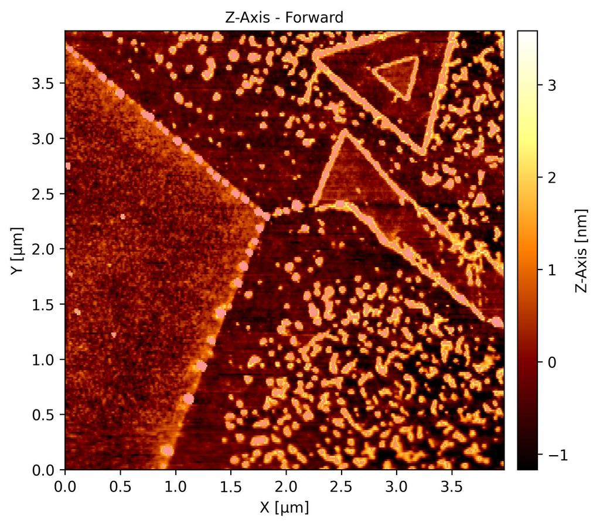

```python
afm.set_mask(afm.array() > 2e-9)
afm.flatten(order=1, fit_on="exclude")

fig = afm.image(color_range="p1", show_mask=True)
plt.show()
```

## Figures for a report

The same call with a scale bar and without a title, and a dark version. To keep a figure, use `fig.savefig("MoS2.png")`.

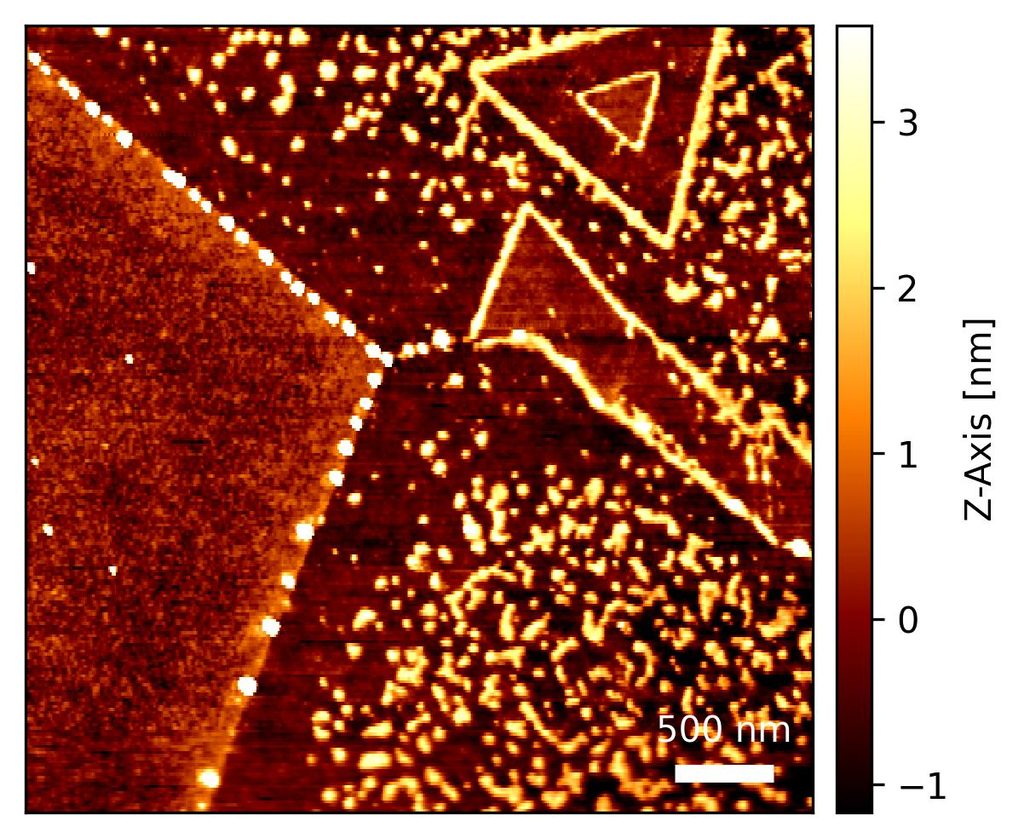

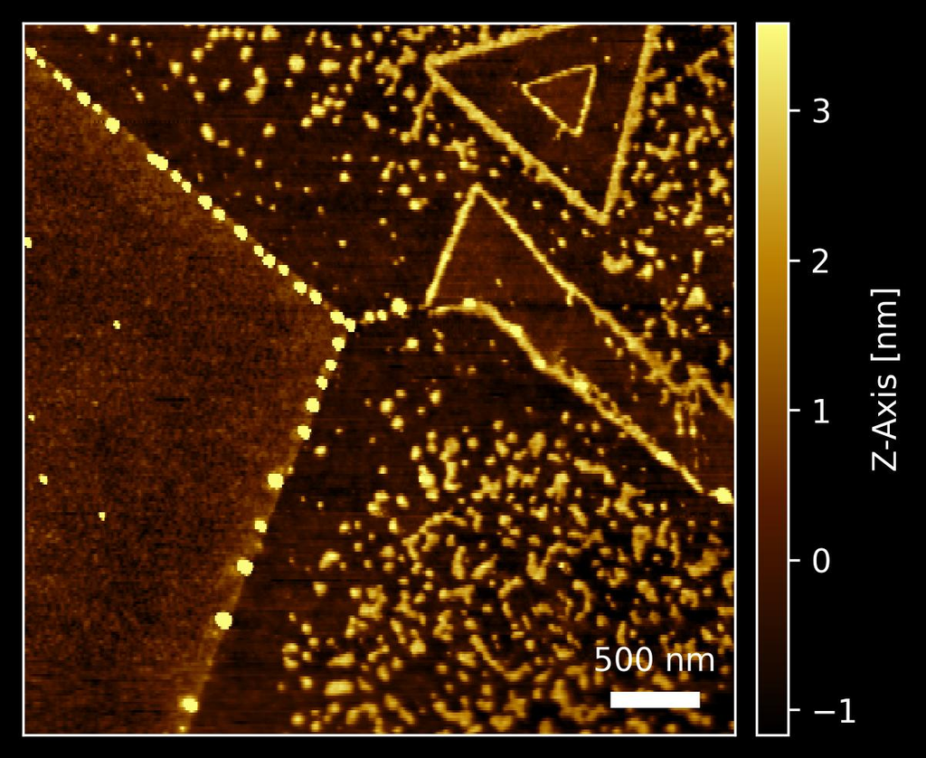

```python
fig = afm.image(color_range="p1", scalebar=True, title=None, figsize=(5, 4))
plt.show()

fig = afm.image(color_range="p1", scalebar=True, title=None, figsize=(5, 4), theme="dark", cmap="Gold")
plt.show()
```

Pass `ax=` to put several plots into one figure. `layout='constrained'` keeps their labels apart.

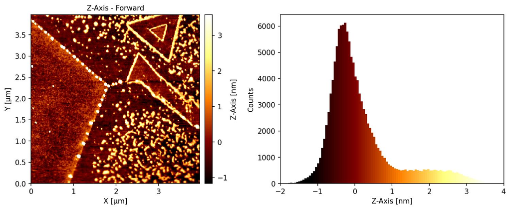

```python
fig, axes = plt.subplots(1, 2, figsize=(10, 4), layout="constrained", dpi=150)
afm.image(ax=axes[0], color_range="p1")
afm.hist(ax=axes[1], color_range="p1", bins=500)
axes[1].set_xlim(-2, 4)  # in nm; the few high spikes would otherwise stretch the axis to 25 nm
plt.show()
```

## 3D

`z_scale` sets how tall the height range looks. `plot3d` colors by height, or draws a `material` under a light; `rotation`, `tilt` and `light` change the view, see `help(afm.plot3d)`.

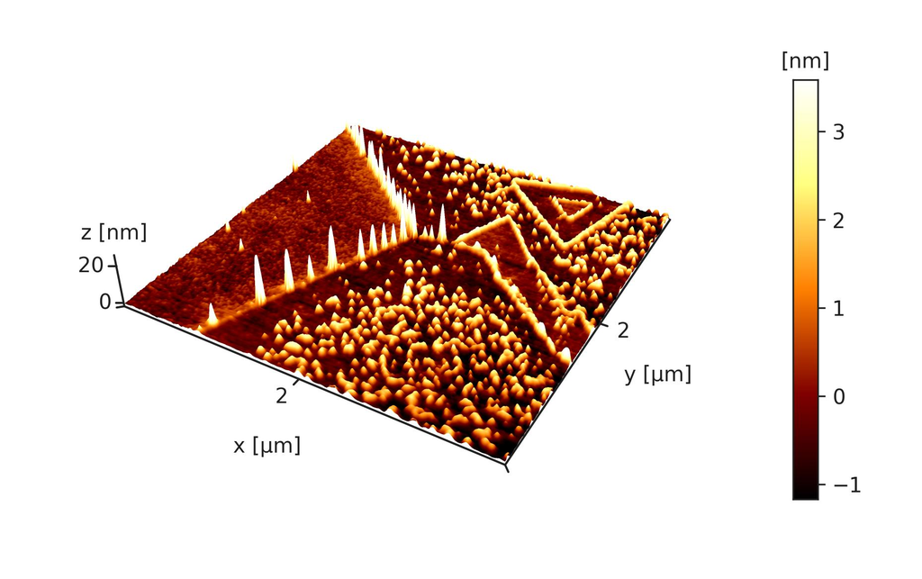

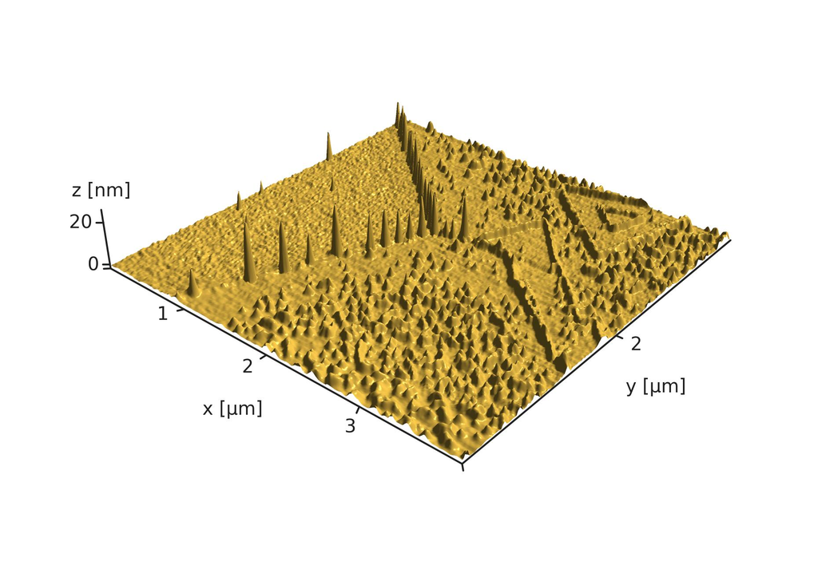

```python
fig = afm.plot3d(color_range="p1", z_scale=0.15)
plt.show()

fig = afm.plot3d(material="Gold", z_scale=0.15, rotation=-40, tilt=60)
plt.show()
```